# Nationality as a Risk Indicator for Modern Slavery in the UK

Ann Scruggs

1 July 2025

## Introduction

A 2022 UNHCR and British Red Cross [report](https://www.redcross.org.uk/about-us/what-we-do/we-speak-up-for-change/at-risk-exploitation-and-the-uk-asylum-system#:~:text=redcross.org.uk-,Key%20findings,risks%20of%20destitution%20and%20homelessness.) highlighted that UK asylum-seekers face high risks of exploitation that might be mitigated through vulnerability screening. Nationality is one possible indicator of increased risk.

This report introduces a preliminary dataset built from publicly available data. It combines UK asylum statistics with National Referral Mechanism (NRM) data on individuals referred as potential victims of modern slavery, organized by nationality and quarter. The dataset is normalized and structured to make it easy to explore trends, ask questions, and illustrate how nationality might relate to vulnerability.

The aim here is not a full analysis, but a demonstration of how a tailored dataset can highlight possible patterns and provide a foundation for deeper research. Code is provided in the appendix.

Data Sources:  
[Immigration system statistics](https://www.gov.uk/government/statistical-data-sets/immigration-system-statistics-data-tables) – quarterly counts of asylum-seekers by nationality  
[National Referral Mechanism (NRM)](https://www.gov.uk/government/collections/national-referral-mechanism-statistics) – quarterly counts of individuals referred as potential victims of modern slavery, by nationality

## Dataset: Asylum Seeker and Slavery Victim Referrals

The new dataset presented below merges asylum-seeker counts with NRM referrals by nationality over time, enabling comparative analysis of nationalities seeking asylum and those potentially at risk of modern slavery in the UK.

| Date_by_Quarter | Nationality | Asylum_Seeker_Count | Referral_Count |
| --- | --- | --- | --- |
| 2025-06-30 | Afghanistan | 10875 | 103 |
| 2025-06-30 | Albania | 3813 | 516 |
| 2025-06-30 | Algeria | 1068 | 13 |
| 2025-06-30 | Angola | 251 | 0 |
| 2025-06-30 | Antigua and Barbuda | 26 | 0 |
| 2025-06-30 | Argentina | 35 | 6 |
| 2025-06-30 | Armenia | 10 | 0 |
| 2025-06-30 | Aruba (Dutch) | 5 | 0 |
| 2025-06-30 | Australia | 4 | 0 |
| 2025-06-30 | Austria | 1 | 1 |

[output cut: 1789 more lines]

Below is the dataset again, now enhanced with additional insights. The underlying dataset remains the same, but the following transformations have been applied to provide more context and comparative metrics:

- `Total_Asylum_Pop_Per_Date` - total asylum-seeker population per date
- `Pct_of_Asylum_Pop` - each row’s Asylum_Seeker_Count as a proportion of the total asylum population on that date.
- `Total_Referrals_Per_Date` - total victim referrals per date
- `Pct_of_Total_Referrals` – each row’s Referral_Count as a proportion of the total referrals on that date.

| Date_by_Quarter | Nationality | Asylum_Seeker_Count | Pct_of_Asylum_Pop | Referral_Count | Pct_of_Total_Referrals | Total_Asylum_Pop_Per_Date | Total_Referrals_Per_Date |
| --- | --- | --- | --- | --- | --- | --- | --- |
| 2025-06-30 | Afghanistan | 10875 | 10.25 | 103 | 2.56 | 106075 | 4026 |
| 2025-06-30 | Albania | 3813 | 3.59 | 516 | 12.82 | 106075 | 4026 |
| 2025-06-30 | Algeria | 1068 | 1.01 | 13 | 0.32 | 106075 | 4026 |
| 2025-06-30 | Angola | 251 | 0.24 | 0 | 0 | 106075 | 4026 |
| 2025-06-30 | Antigua and Barbuda | 26 | 0.02 | 0 | 0 | 106075 | 4026 |
| 2025-06-30 | Argentina | 35 | 0.03 | 6 | 0.15 | 106075 | 4026 |
| 2025-06-30 | Armenia | 10 | 0.01 | 0 | 0 | 106075 | 4026 |
| 2025-06-30 | Aruba (Dutch) | 5 | 0 | 0 | 0 | 106075 | 4026 |
| 2025-06-30 | Australia | 4 | 0 | 0 | 0 | 106075 | 4026 |
| 2025-06-30 | Austria | 1 | 0 | 1 | 0.02 | 106075 | 4026 |

[output cut: 1789 more lines]

# **Initial Visual Insights**

## Who is most at risk?

#### Depicted here are the top 10 nationalities of potential victims of modern slavery since 2023 in the UK.

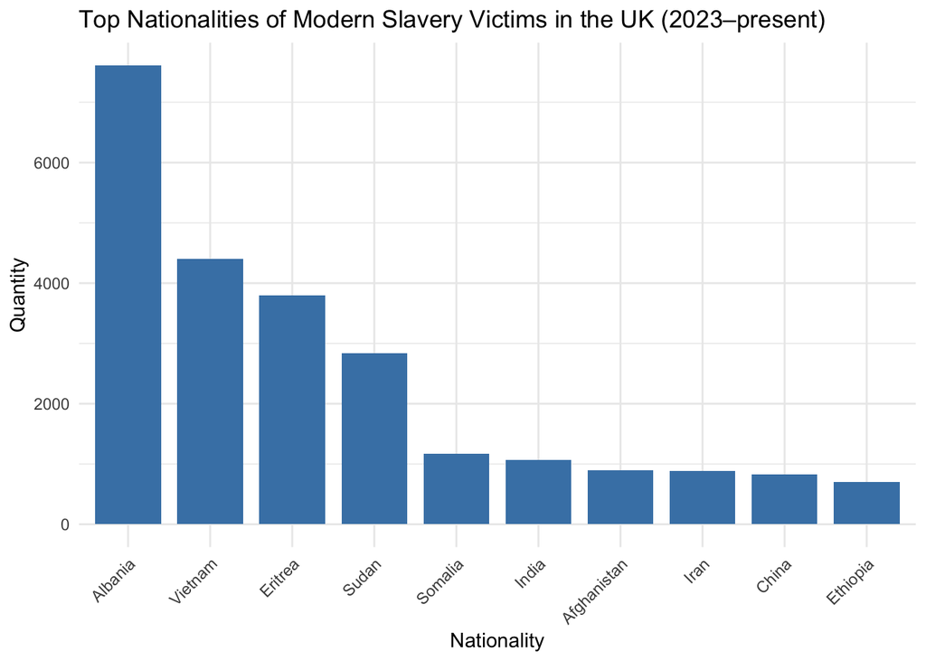

#### Since 2023, top asylum-seeker nationalities in the UK—Iran, Afghanistan, Eritrea, Albania, and Sudan—are also among the largest groups of potential modern slavery victims.

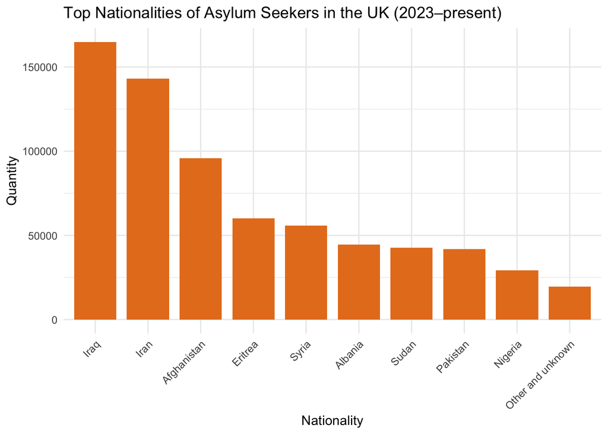

#### This data enables nationality-specific insights. Illustrated here are the asylum and referral patterns for Albania and Vietnam since 2023.

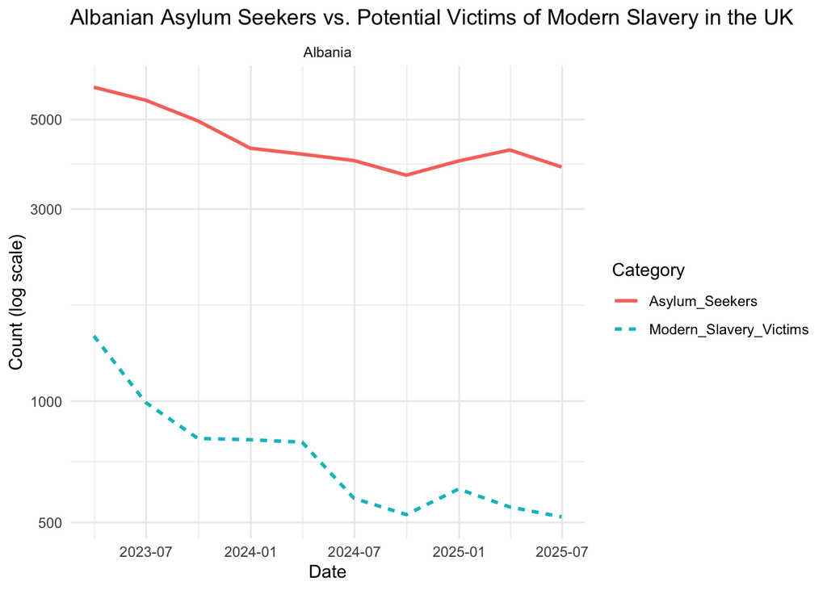

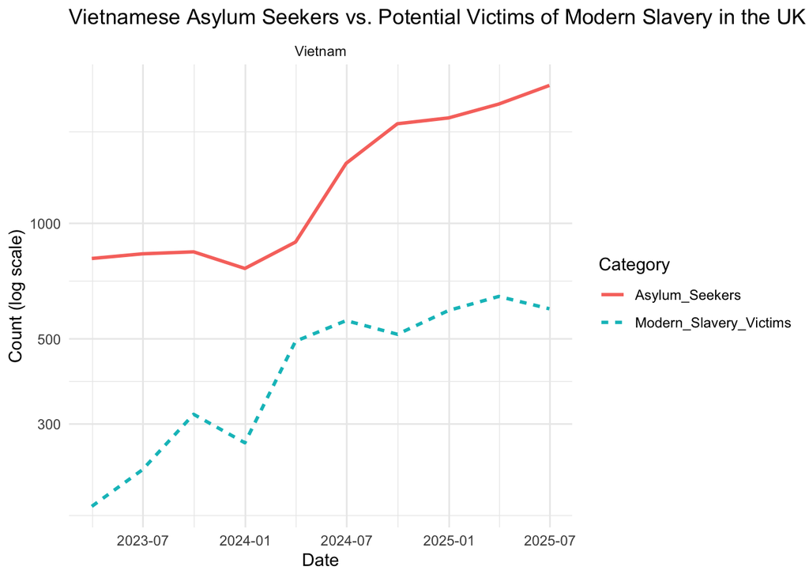

## Appendix: All code

```r
knitr::opts_chunk$set(echo = FALSE)

#Loading relevent packages for report
suppressMessages(library(tidyverse))
suppressMessages(library(readr))
suppressMessages(library(readxl))
suppressMessages(library(dplyr))
suppressMessages(library(RSelenium))
suppressMessages(library(rvest))
suppressMessages(library(readODS))
suppressMessages(library(ggplot2))
suppressMessages(library(scales))
suppressMessages(library(patchwork))
suppressMessages(library(DBI))
suppressMessages(library(bigrquery))
suppressMessages(library(janitor))

#setting local directory (update this to relevant location on your computer)
ddir <- "~/Documents/LSE/Dissertation/Asylum_ModernSlavery/My report"

#checking if the directory exists, and if not, creating it
if(dir.exists(ddir)){
  invisible(NULL) #preventing default NULL message if it exists
  } else { dir.create(ddir) }

#making a function to download data through a URL
downloader <- function(link) {

  #setting download URL
  url <- link

  #creating path for the file
  path <- url %>%  #starting with url
    str_extract("/([^/]+)$") %>%  #extracting file name
    paste0(ddir, "/", .) #pasting to ddir with correct structure

  #checking if already downloaded, and if not, downloading to path
  if(file.exists(path)) { } else {
    download.file(url, path)
  }

  #returning the path so its possible to retrieve
  return(path)
}

#Run asylum_data through downloader().

#defining url
asylum_by_nat_url <- "https://assets.publishing.service.gov.uk/media/6748453624108edc3c8ceb3a/asylum-seekers-receipt-support-datasets-sep-24.xlsx"

#downloading using function created earlier
local_file <- downloader(asylum_by_nat_url)

#reading in the data & suppressing message regarding column names (these will be addressed later)
raw_asylum_data <- suppressMessages(read_excel(local_file, #specificying file path
                           sheet = "Data_Asy_D09")) #specifying sheet to read in
#########################################################################
#download raw data from BigQuery and skip to "Normalising Data" portion
#########################################################################

#connecting to database
db <- dbConnect(
  bigrquery::bigquery(),
  project = "asylum-modernslavery", #assigning created project name
  dataset = "asylum_referral_data", #assigning created dataset name
  billing = "asylum-modernslavery" #assigning project name in lieu of billing
)

#loading in the NRM secondary data
untidy_full_nrm_data <- dbGetQuery(db, "SELECT * FROM untidy_full_nrm_data")

#########################################################################
# Read in the webpage and scrape to find each page title.
#########################################################################

#setting URL for base webpage
url <- "https://www.gov.uk/government/collections/national-referral-mechanism-statistics"

#reading in url
html <- read_html(url)

#scraping to find just page titles using css selector
titles_element <- html_elements(html,
                                css = ".gem-c-document-list__item-title .gem-c-force-print-link-styles")

#extracting just the text and defining
page_titles <- html_text(titles_element)

#creating function to return only quarterly titles based on year
get_titles <- function(year) {  #setting argument to year

  #returning titles that have the relevant year and do not contain the word "summary"
  return(page_titles[grepl(as.character(year), page_titles) &
                       !grepl("summary", page_titles)])
}


#setting vector with desired years of data
desired_data <- c(2023,2024,2025) #edit this if desired

#initializing an empty vector to store the results
all_titles_vector <- character()

#looping through each year and collecting titles
for (year in desired_data) { #setting loop to iterate over vector with years

  titles_for_year <- get_titles(year)  #running year through get_titles function

  all_titles_vector <- c(all_titles_vector, titles_for_year)  #appending the results to the vector
}

#########################################################################
#Initialize a Selenium server and navigate to NRM Statistics webpage.
#########################################################################

#starting Selenium server
rD <- rsDriver(
  browser = "firefox",
  geckover = "latest",       # ensures correct GeckoDriver
  phantomver = NULL,          # disables PhantomJS download
  verbose = FALSE,
  port = netstat::free_port(random = TRUE)
)

#setting driver
driver <- rD$client

#navigating to set URL
driver$navigate(url)

#delaying
Sys.sleep(7)

#finding accept button with relevant xpath
accept_button <- driver$findElement(using = "xpath",
                                    value = "//button[text() = 'Accept additional cookies']")

#uncomment this line to use the reject_buttom
#reject_button <- driver$findElement(using = "xpath", value = "//button[text() = 'Reject additional cookies']")

#delaying
Sys.sleep(3)

#clicking accept_button
accept_button$clickElement()

#delaying
Sys.sleep(4)

#########################################################################
#Iterate over each gathered page title. The loop navigates to each webpage and extracts the relevant datatable’s url.
#########################################################################

#initializing empty vector to store results
all_links <- character()

#starting for loop
for (i in all_titles_vector) { #setting to iterate over each title obtained

  #using title to create xpath that leads to page link
  path <- paste0("//a[text() = ","'",i,"'","]")

  #finding page link with path created
  next_page <- driver$findElement(using = "xpath", value = path)

  #delaying
  Sys.sleep(6)

  #scrolling down to page link (found that element would not click if not in view)
  scroll <- driver$executeScript("arguments[0].scrollIntoView(true);", list(next_page))

  #delaying
  Sys.sleep(2)

  #clicking page element
  next_page$clickElement()

  #delaying
  Sys.sleep(15)

  #finding the element with an xpath for the first .ods link
  link_element <- driver$findElement(using = "xpath", value = "//a[contains(@href, '.ods')][1]")
```

```r
  #delaying
  Sys.sleep(5)

  #extracting the href attribute (download url)
  ods_link <- link_element$getElementAttribute("href")[[1]]

  #delaying
  Sys.sleep(5.5)

  #adding download url to all_links
  all_links <- c(all_links, ods_link)

  #navigating back to previous page before next iteration
  driver$goBack()

  #delaying
  Sys.sleep(25)
}

#ending Selenium session
driver$close()
rD$server$stop()

#running all links through the downloader function
for (i in all_links) {
  downloader(i)
}
#finding file path names as saved in local ddir
file_paths <- list.files(ddir, full.names = TRUE)

#filtering for only files containing "referral" in the names
nrm_file_paths <- grep("referral", file_paths, value = TRUE, ignore.case = TRUE)

#setting vector of sheet names to read in - in order over nrm_file_paths
sheet_name <- c("Table_5","Table_7","Table_7","Table_5","Table_7","Table_7","Table_5", "Table_7", "Table_5", "Table_7")

#creating cleaning function
nrm_read_clean <- function(nrm_file_paths, sheet_name) { #setting arguments

  #reading in the data & suppressing message regarding column names (these will be addressed later)
  nrm <- suppressMessages(read_ods(nrm_file_paths, #specificying file path
                       sheet = sheet_name)) #specifying sheet to read in

  #locating position of "Total" sections where the relevant data is
  total_row <- which(nrm[, 1] == "Total")

  #subsetting to select only the rows below this "Total" category and removing the first column
  subset_nrm <- nrm[(total_row + 1):nrow(nrm),-1 ]

  #selecting only the first and last column
  subset_nrm <- subset_nrm[, c(1, ncol(subset_nrm))]

  #modifying column names
  colnames(subset_nrm) <- c("Nationality", "Referral Count")

  #modifying the Referral Count column as numeric
  subset_nrm$`Referral Count` <- as.numeric(subset_nrm$`Referral Count`)

  #returning the final dataset
  return(subset_nrm)
}

#initializing an empty list to store results
nrm_data <- list()

#starting for loop to iterate over each downloaded nrm file
for (i in seq_along(nrm_file_paths)) { #setting to sequence so files match sheet names

  #running each nrm file through the nrm_read_clean function with the relevant sheet
  suppressMessages(nrm_data[[i]] <- nrm_read_clean(nrm_file_paths[i],
                                                   sheet = sheet_name[i]))
}
#extracting the relevant quarters from the file paths
quarters <- nrm_file_paths %>%
  str_extract_all("(?<=quarter-)(\\d+)(?=-\\d{4})")

#extracting the relevant years from the file paths
year <- nrm_file_paths %>%
  str_extract_all("\\d{4}")

#creating function to map quarters to the last day of the quarter
get_date <- function(quarter, year) {
  if (quarter == 1) {
    return(paste("31-03-", year, sep = "")) #returning last day of quarter 1
  } else if (quarter == 2) {
    return(paste("30-06-", year, sep = "")) #returning last day of quarter 2
  } else if (quarter == 3) {
    return(paste("30-09-", year, sep = "")) #returning last day of quarter 3
  } else if (quarter == 4) {
    return(paste("31-12-", year, sep = "")) #returning last day of quarter 4
  }
}

#initializing empty list to store results
dates <- list()

#setting loop to iterate along the quarters vector in order
for (i in seq_along(quarters)) { #sequencing along to maintain order

  #running get_date function to extract relevant quarter and year info
  current_date <- get_date(quarters[i],year[i])

  #saving dates
  dates <- c(dates,current_date)
}

#unlisting dates so it behaves as a regular vector
dates <- unlist(dates)

#initiating an empty list to store our data
full_nrm_data <- list()

#running a for loop to sequence along each nrm tibble and add a year column
for (i in seq_along(nrm_data)) {  #sequencing along

  #setting the current date
  current_date <- dates[i]

  #adding Date column by mutating
  tibble <- nrm_data[[i]] %>%
    mutate("Date" = (current_date))

  #appending the result to the combined tibble
  full_nrm_data <- bind_rows(full_nrm_data, tibble)

}

#assinging differentiating name to appended data
untidy_full_nrm_data <- full_nrm_data
##########################################################################
#The ISO-3166 Dataset is used to normalise nationality to country names between NRM and asylum_data.
#Run the URL through downloader(). Using the top guess from html_encoding_guess, read the file in.
##########################################################################

#setting URL for ISO - 3166
iso_url <- "https://t2a.io/assets/blog-move/uploads/2014/03/Countries-List.csv"

#running url through the downloader function
file <- downloader(iso_url)

#guessing encoding
guess <- html_encoding_guess(file)

#reading in with top encoding guess
iso_raw <- suppressMessages(read_csv(file, locale = locale(encoding = "ISO-8859-1")))
##########################################################################
#Tidying Data
##########################################################################

#replacing headers with the first row
new_headers <- raw_asylum_data[1, ]  #extracting the first row as headers
asylum_data <- raw_asylum_data[-1, ]  #removing the first row from the data
colnames(asylum_data) <- new_headers  #setting the new headers

#renaming Date column
asylum_data <- asylum_data %>%
  rename(Date = `Date (as at…)`) #renaming to "Date"

#formating Date column as date
asylum_data$Date <- as.Date(asylum_data$Date, format = "%d %b %Y")

#formating People column as integer
asylum_data$People <- as.numeric(asylum_data$People)

#grouping and summarising for relevant data
asylum_data <- asylum_data %>%
  group_by(Date,Nationality) %>% #grouping by Date and Nationality

  #summarising to get column with sum of people seeking asylum
  summarise("Asylum_Seeker_Count" = sum(People),

            ### * the following line of code was generated by AI/ChatGPT
            .groups = "keep") #keeping all grouping variables
#Tidy the format of the NRM data
#modifying date format and selecting columns in new order
full_nrm_data <- untidy_full_nrm_data %>%
  mutate(Date = as.Date(Date, format = "%d-%m-%Y")) %>% #updating format to match asylum date format
  select(Date,Nationality,`Referral Count`) #selecting columns
```

```r
#filtering for dates greater than or equal to the earilest date in full_nrm_data
asylum_data <- asylum_data %>%
  filter(Date >= as.Date(min(full_nrm_data$Date))) #using min to find earliest date

#selecting relevant columns from data
iso_data <- iso_raw %>%
  select(Name,`Demonym 1`,`Demonym 2`,`Demonym 3`)

#pivoting data longer to include all Demonyms (Nationalities) in one column
long_iso_data <- iso_data %>%
  pivot_longer(cols = c(`Demonym 1`,`Demonym 2`,`Demonym 3`), #pivoting Demonym columns
               names_to = "DemonymNumber",  #setting  names
               values_to = "Nationality",  #setting name for values column
               values_drop_na = TRUE) %>% #dropping NAs
  select("Nationality", Name) %>% #selecting necessary columns
  rename("Country" = Name) #renaming for readability

#defining every unique country found in the asylum_data
countries <- unique(asylum_data$Nationality)

#filtering iso data for any country in asylum data
asylum_iso <- long_iso_data %>%
  filter(Country %in% countries)

#filtering full_nrm_data for any nationality located in the asylum_iso
filtered_nrm <- full_nrm_data %>%
  filter(Nationality %in% asylum_iso$Nationality)


#performing a left join by Nationality
nrm_for_asylum <- filtered_nrm %>%
  left_join(asylum_iso %>%

              ### * the following line of code was generated by AI/ChatGPT
              distinct(Nationality, .keep_all = TRUE),  #ensuring only one mapping per nationality

            by = "Nationality") %>% #joining by Nationality
  select(-Nationality) %>% #removing Nationality column
  rename(Nationality = Country) #Renaming

#using a left join to combine the datasets by Date and Nationality
join <- asylum_data %>%
  left_join(nrm_for_asylum, by = c("Date", "Nationality"))

#mutating so any rows with no Referral Counts will show 0 instead of NA
asylum_referral_data <- join %>%
  mutate(`Referral Count` = ifelse(is.na(`Referral Count`), 0, `Referral Count`)) %>%
  arrange(desc(Date)) #arranging by date

#renaming columns
asylum_referral_data <- asylum_referral_data %>%
  rename("Referral_Count" = `Referral Count`, "Date_by_Quarter" = Date) #using underscores instead of spaces

library(reactable)

reactable(
  asylum_referral_data,
  filterable = TRUE,
  searchable = TRUE,
  pagination = TRUE,
  highlight = TRUE,
  striped = TRUE,
  style = list(color = "#1F77B4")  # classic blue

)
#######################################################################
#adding additional transformations to report
#######################################################################

#Including "N/A - Subsistence Only (Dec 2023 - Sep 2024)" in the unknown category
asy_refer_transformed <- asylum_referral_data %>%

  #setting ifelse statement within mutated column to modify correct cells
  mutate(Nationality = ifelse(Nationality == "N/A - Subsistence Only (Dec 2023 - Sep 2024)",
                                    "Other and unknown", Nationality))

#defining a function to calculate total asylum seekers per date
total_calculator <- function(date, data) {
  sum(data$Asylum_Seeker_Count[data$Date_by_Quarter == date])
}

#adding new column for total asylum population for each date
asy_refer_transformed <- asy_refer_transformed %>%

  ### * the following line of code was generated by AI/ChatGPT
  #sapply uses the total_calculator to calculate total across every specific date
  mutate(Total_Asylum_Pop_Per_Date = sapply(Date_by_Quarter, total_calculator, data = asy_refer_transformed))
#mutating to add percentage column
asy_refer_transformed <- asy_refer_transformed %>%

  #finding percentage by dividing asylum seeker count by new population column
  mutate("Pct_of_Asylum_Pop" =
           #multiplying to get percent and rounding to 2 decimals
           round((Asylum_Seeker_Count / Total_Asylum_Pop_Per_Date)*100,2))
#defining a function to calculate total referrals per date
total_calculator <- function(date, data) {
  sum(data$Referral_Count[data$Date_by_Quarter == date])
}

#adding new column for total referrals for each date
asy_refer_transformed <- asy_refer_transformed %>%

  ### * the following line of code was generated by AI/ChatGPT
  #sapply uses the total_calculator to calculate total across every specific date
  mutate("Total_Referrals_Per_Date" = sapply(Date_by_Quarter, total_calculator, data = asy_refer_transformed))
#mutating to add percentage column
asy_refer_transformed <- asy_refer_transformed %>%

  #finding percentage by dividing referral count by new population column
  mutate("Pct_of_Total_Referrals" =
           #multiplying to get percent and rounding to 2 decimals
           round((Referral_Count / Total_Referrals_Per_Date) * 100, 2))
#selecting columns in more readable way
asylum_referral_transform <- asy_refer_transformed %>%
  select(Date_by_Quarter,Nationality,
         Asylum_Seeker_Count,Pct_of_Asylum_Pop,
         Referral_Count,Pct_of_Total_Referrals,
         Total_Asylum_Pop_Per_Date,Total_Referrals_Per_Date)

reactable(
  asylum_referral_transform,
  filterable = TRUE,
  searchable = TRUE,
  pagination = TRUE,
  highlight = TRUE,
  striped = TRUE,
  style = list(color = "#1F77B4")  # classic blue

)

#grouping and summarising data to show total referrals and asylum seekers by Country of origin
data_by_nationality <- asy_refer_transformed %>%
  group_by(Nationality) %>% #grouping by nationality
  summarise("Total_Referral" = sum(Referral_Count), #summing referral count
            "Total_Asylum" = sum(Asylum_Seeker_Count)) #summing asylum seeker count

#arranging and slicing to get top 10 most referred
data_by_nat_slice <- data_by_nationality %>%
  arrange(desc(Total_Referral)) %>%
  slice_head(n=10) #slicing off the top 10

#vector of just 10 countries
top_nations_referred <- data_by_nat_slice$Nationality

#pivoting longer to put counts in same column
longer_data <- asy_refer_transformed %>%
  pivot_longer(cols = c(Asylum_Seeker_Count, Referral_Count),
               names_to = "Count_Type",
               values_to = "Quantity")
```

```r
#plotting
top10_victim_plot <- data_by_nat_slice %>%

  #setting x argument to Country but ordered by count not alphabet
  ggplot(aes(x = reorder(Nationality, Total_Referral, decreasing = TRUE),
             y = Total_Referral)) + #coloring by Count_Type
  geom_bar(stat = "identity", position = "dodge",  width = 0.8, fill = "steelblue") + #setting format

  #customizing titles and labels
  labs(y = "Quantity",
       x = "Nationality",
       title = "Top Nationalities of Modern Slavery Victims in the UK (2023–present)") +
  theme_minimal() + #setting theme
  theme(axis.text.x = element_text(angle = 45, hjust = 1))  #setting labels diagonally for readability

top10_victim_plot
#plotting top 10 for only 2025
top10_plot_2025 <- asy_refer_transformed %>%

  filter(year(Date_by_Quarter) == 2025) %>%
  group_by(Nationality) %>%
  summarise(Total_Referral = sum(Referral_Count, na.rm = TRUE)) %>%
  slice_max(order_by = Total_Referral, n = 10) %>%


  #setting x argument to Country but ordered by count not alphabet
  ggplot(aes(x = reorder(Nationality, Total_Referral , decreasing = TRUE),
             y = Total_Referral)) +
  geom_bar(stat = "identity", position = "dodge",  width = 0.8, fill = "steelblue") + #setting format

  #customizing titles and labels
  labs(y = "Quantity",
       x = "Nationality",
       title = "Top Nationalities of Modern Slavery Victims in the UK (2025)") +
  theme_minimal() + #setting theme
  theme(axis.text.x = element_text(angle = 45, hjust = 1))  #setting labels diagonally for readability

#plotting top ten nationalities seeking asylum
top10_asylum_plot <- data_by_nationality %>%

  slice_max(order_by = Total_Asylum, n = 10) %>%

  #setting x argument to Country but ordered by count not alphabet
  ggplot(aes(x = reorder(Nationality, Total_Asylum, decreasing = TRUE),
             y = Total_Asylum)) + #coloring by Count_Type
  geom_bar(stat = "identity", position = "dodge",  width = 0.8, fill = "#E67E22") + #setting format

  #customizing titles and labels
  labs(y = "Quantity",
       x = "Nationality",
       title = "Top Nationalities of Asylum Seekers in the UK (2023–present)") +
  theme_minimal() + #setting theme
  theme(axis.text.x = element_text(angle = 45, hjust = 1))  #setting labels diagonally for readability

top10_asylum_plot

#focusing in on Albania
focus_nations <- "Albania"

plot1 <- asy_refer_transformed %>%
  filter(Nationality %in% focus_nations) %>%
  group_by(Date_by_Quarter, Nationality) %>%
  summarise(
    Asylum_Seekers = sum(Asylum_Seeker_Count, na.rm = TRUE),
    Modern_Slavery_Victims = sum(Referral_Count, na.rm = TRUE),
    .groups = "drop"
  ) %>%
  pivot_longer(cols = c("Asylum_Seekers", "Modern_Slavery_Victims"),
               names_to = "Type",
               values_to = "Count") %>%
  ggplot(aes(x = Date_by_Quarter, y = Count, color = Type, linetype = Type)) +
  geom_line(linewidth = 1) +
  facet_wrap(~Nationality, scales = "free_y") +
  scale_x_date(date_labels = "%Y-%m") +
  scale_y_log10() +   # 🔑 log-transform
  labs(
    title = "Albanian Asylum Seekers vs. Potential Victims of Modern Slavery in the UK",
    y = "Count (log scale)",
    x = "Date",
    color = "Category",
    linetype = "Category"
  ) +
  theme_minimal()

plot1
#focusing in on vietnam
focus_nations <- "Vietnam"

plot1 <- asy_refer_transformed %>%
  filter(Nationality %in% focus_nations) %>%
  group_by(Date_by_Quarter, Nationality) %>%
  summarise(
    Asylum_Seekers = sum(Asylum_Seeker_Count, na.rm = TRUE),
    Modern_Slavery_Victims = sum(Referral_Count, na.rm = TRUE),
    .groups = "drop"
  ) %>%
  pivot_longer(cols = c("Asylum_Seekers", "Modern_Slavery_Victims"),
               names_to = "Type",
               values_to = "Count") %>%
  ggplot(aes(x = Date_by_Quarter, y = Count, color = Type, linetype = Type)) +
  geom_line(linewidth = 1) +
  facet_wrap(~Nationality, scales = "free_y") +
  scale_x_date(date_labels = "%Y-%m") +
  scale_y_log10() +   # 🔑 log-transform
  labs(
    title = "Vietnamese Asylum Seekers vs. Potential Victims of Modern Slavery in the UK",
    y = "Count (log scale)",
    x = "Date",
    color = "Category",
    linetype = "Category"
  ) +
  theme_minimal()

plot1

#setting local directory for outputs
odir <- "~/Documents/LSE/Dissertation/Asylum_ModernSlavery"

#checking if the directory exists, and if not, creating it
if(dir.exists(odir)){ } else { dir.create(odir) }
#creating function to check if already downloaded, and if not, downloading to path
output_saver <- function(data, filename) {

  path <- paste0(odir, "/", filename)

  if(file.exists(path)) { } else {
  write.csv(data, path) }
}

#saving tabular data
output_saver(asylum_referral_data, "asylum_referral_data.csv")

#saving transformed data
output_saver(asy_refer_transformed, "asylum_referral_transform.csv")

#identifying project name (project ID)
project_name <- "asylum-modernslavery"

#identifiying billing (project ID)
billing_id <- "asylum-modernslavery"

#identifying dataset name (created on website)
dataset_name <- "asylum_referral_data"

#connecting to remote database using defined variables above
db <- dbConnect(
  bigrquery::bigquery(),
  project = project_name,
  dataset = dataset_name,
  billing = billing_id
)

###########################################
#Primary Data
###########################################

#loading raw_asylum_data to database
raw_asylum_data <- raw_asylum_data %>% clean_names() #cleaning columns to satsify BigQuery requirments
dbWriteTable(db, "raw_asylum_data", raw_asylum_data) #loading to db

###########################################
#Secondary Data
###########################################

#loading untidy_full_nrm_data to database
dbWriteTable(db, "untidy_full_nrm_data", untidy_full_nrm_data)

#loading iso_raw data to database
iso_raw <- iso_raw %>% clean_names() #cleaning columns to satsify BigQuery requirments
dbWriteTable(db, "raw_iso_data", iso_raw) #loading to db

###########################################
#New Data
###########################################
```

```r
#loading new tabular data to database
dbWriteTable(db, "final_asylum_referral", asylum_referral_data)

#loading new transformed data to database
dbWriteTable(db, "transformed_asylum_referral", asylum_referral_transform)

#disconnecting database
dbDisconnect(db)
rm(db)
# this chunk generates the complete code appendix.
# eval=FALSE tells R not to run (``evaluate'') the code here (it was already run before).
```